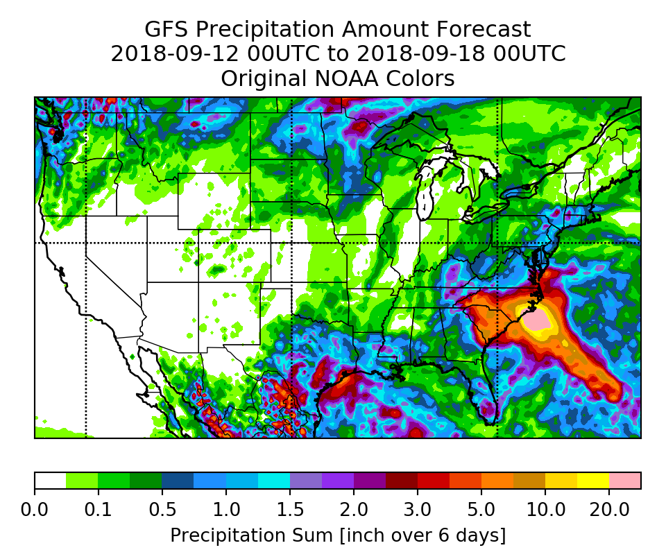

```python
# Original NOAA color map and levels
noaahex = ["#ffffff", "#7fff00", "#00cd00", "#008b00", "#104e8b",
           "#1e90ff", "#00b2ee", "#00eeee", "#8968cd", "#912cee",
           "#8b008b", "#8b0000", "#cd0000", "#ee4000", "#ff7f00",
           "#cd8500", "#ffd700", "#ffff00", "#ffaeb9"]
lev     = [0., 0.01, 0.1, 0.25, 0.50, 0.75, 1.0, 1.25, 1.50, 1.75, 2.0,
           2.5, 3.0, 4.0, 5.0, 7.0, 10.0, 15.0, 20.0, 60.0]
from colorspace import deutan
demo(lev, noaahex, titles = ["Original NOAA Colors"])
```

This is still a very common way to visualize such data sets using flashy (in)famouse RGB rainbow based color palettes, mainly due to historical reasons. The example above uses the color map and contour levels as the original figure published by the National Oceanic and Atmospheric Administration (NOAA; noaa.gov).

This color map exhibits multiple color issues such as strong gradients in luminance (light to dark to light to dark colors), mainly vivid and fully saturated colors, and colors which are very similar (around 1 inch).

In a first step let\u2019s check what might possibly go wrong with this color map. Remember: what you would like to do with these kind of visualizations is to warn the inhabitants of your country about extreme precipitation amounts and possible flood events connected to them. The local population, but also fire fighters and disaster management services, are your customer in this case. Up to 5 percent (in Europe about 10 percent) of the local population have visual constraints such as deuteranomaly (red-green weakness). Furthermore, these forecasts might be printed or displayed on gray scale devices (e.g., newspaper) wherefore the color map should work in all cases.

The two plots below show how people with deuteranomaly perceive the image (left) and how the image looks in gray scale (right).

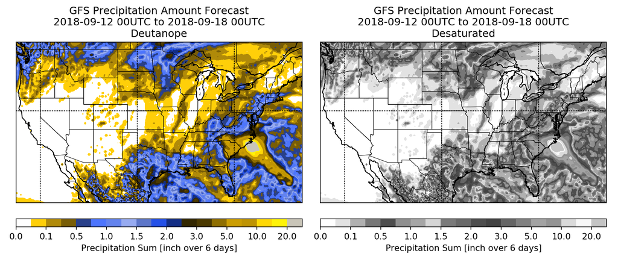

```python
from colorspace import deutan, desaturate
demo(lev, deutan(noaahex), desaturate(noaahex),
     titles = ["Deutanope", "Desaturated"])
```

The effectiveness of the colormap completely collapses in both cases as the mapping between colors and values is no more unique and the large differences in luminance guides the reader to areas where only moderate precipitation sums are expected. Large parts of these problems can be solved by simply replacing the color map!

Let\u2019s try something as follows:

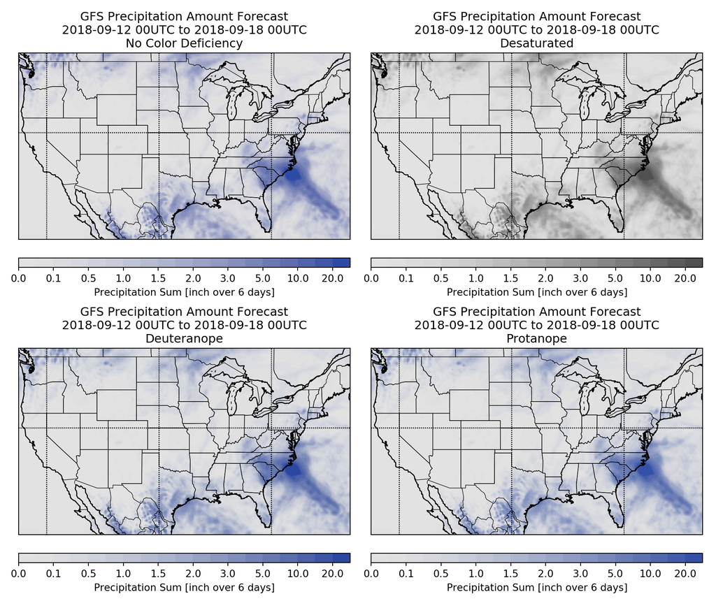

```python
from colorspace import sequential_hcl, desaturate, deutan, protan
hex = sequential_hcl("Blues 2", power = 2.5, rev = True)(len(lev))
demo(lev, hex, desaturate(hex), deutan(hex), protan(hex),
    titles = ["No Color Deficiency", "Desaturated", "Deuteranope", "Protanope"])
```

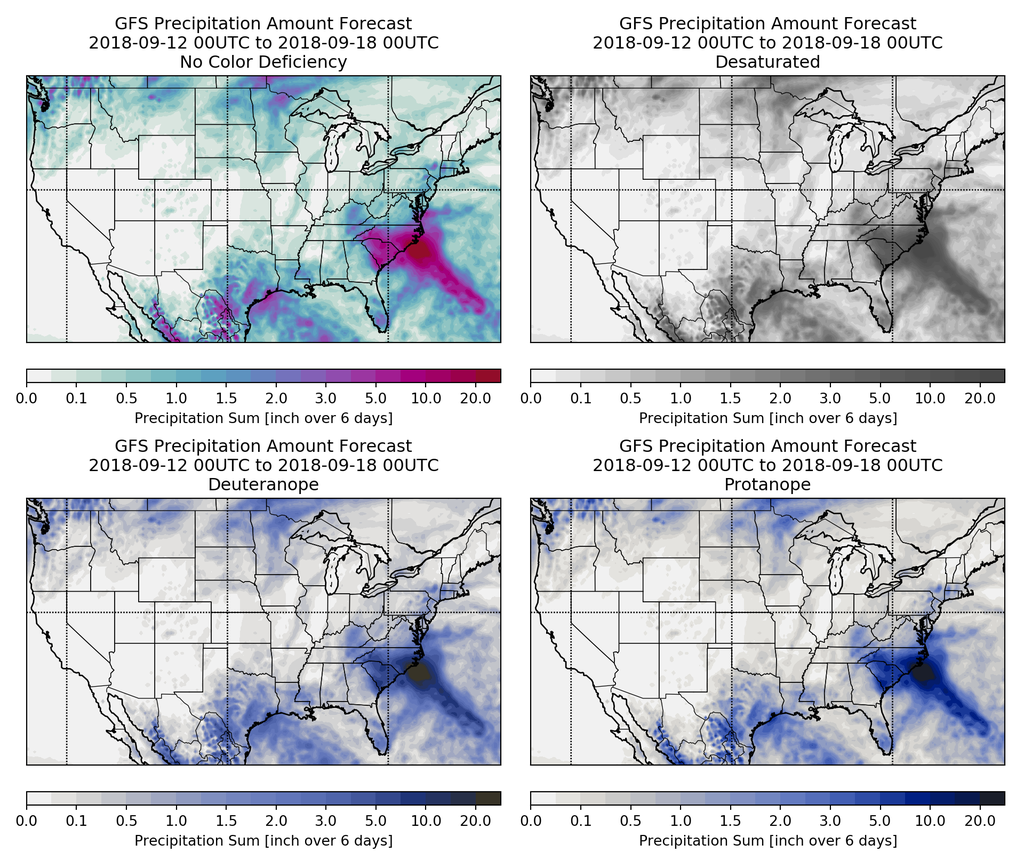

```python
from colorspace import sequential_hcl, desaturate, deutan, protan
hex = sequential_hcl(h = [-220,20], c = [0, 90, 0], l = [95, 30], power = [1.5,1.5])(len(lev))
demo(lev, hex, desaturate(hex), deutan(hex), protan(hex),
    titles = ["No Color Deficiency", "Desaturated", "Deuteranope", "Protanope"])
```